# What are the Economic and Health Consequences of Natural Disasters Between 1950 and 2011?

# Synopsis

The intent of this report is to determine the most impactful natural events with regards to personal health, property, and agriculture. To investigate, data is provided by the U.S. National Oceanic and Atmospheric Administration’s (NOAA) storm database. This database tracks characteristics of major storms and weather events in the United States, including when and where they occur, as well as estimates of any fatalities, injuries, property damage, and crop damage. From these data, it is concluded that, on average across the U.S, tornadoes cause the most injuries as well as fatalities; the most property damage is caused by floods; and the most crop damage is caused by drought.

# Data Processing

From the NOAA Storm Database(https://d396qusza40orc.cloudfront.net/repdata%2Fdata%2FStormData.csv.bz2), data is obtained on events across the US. The database tracks characteristics of major storms and weather events in the United States, including when and where they occur. Data between 1950 and 2011 was used for this analysis. For more info on the Storm database documentation, go to https://d396qusza40orc.cloudfront.net/repdata%2Fpeer2_doc%2Fpd01016005curr.pdf

```r
#READ IN NATURAL DISASTER DATA
dfa1<-read.csv('./repdata%2Fdata%2FStormData.csv.bz2')
```

As expected, this is rather large data set. There are 902297 entries in the data set.

```r
nrow(dfa1)
```

```
## [1] 902297
```

It is preferred to organize this data by date.

```r
dfa1$BGN_DATE<-as.POSIXct(dfa1$BGN_DATE, format="%m/%d/%Y")
dfa1<-dfa1[order(dfa1$BGN_DATE),]
head(dfa1)
```

```
##        STATE__   BGN_DATE BGN_TIME TIME_ZONE COUNTY COUNTYNAME STATE
## 28479       17 1950-01-03     1110       CST    119    MADISON    IL
## 28480       17 1950-01-03     1155       CST    135 MONTGOMERY    IL
## 83316       29 1950-01-03     1100       CST    189  ST. LOUIS    MO
## 114844      39 1950-01-03     1600       CST    161   VAN WERT    OH
## 6348         5 1950-01-13     0525       CST    113       POLK    AR
## 28481       17 1950-01-25     2100       CST     91   KANKAKEE    IL
##         EVTYPE BGN_RANGE BGN_AZI BGN_LOCATI END_DATE END_TIME COUNTY_END
## 28479  TORNADO         0                                               0
## 28480  TORNADO         0                                               0
## 83316  TORNADO         0                                               0
## 114844 TORNADO         0                                               0
## 6348   TORNADO         0                                               0
## 28481  TORNADO         0                                               0
##        COUNTYENDN END_RANGE END_AZI END_LOCATI LENGTH WIDTH F MAG
```

[output cut: 27 more lines]

The column name of interest is labeled “EVTYPE”. There are 985 different types of events. Seeing that this database records events after they happen, NAs are not a concern.

```r
length(levels(factor(dfa1$EVTYPE)))
```

```
## [1] 985
```

## Events most harmful to Population Health

To acquire the impact of events related to personal health, the columns “FATALITIES” and “INJURIES” are used to measure this.

```r
dfa2<-subset(dfa1, (dfa1$FATALITIES | dfa1$INJURIES) > 0)
nrow(dfa2)
```

```
## [1] 21929
```

There are 21929 events that have caused injury or fatality. Let’s find out which events inflict the most harm. Next, we look at the total number of injuries in this database with respect to event type.

```r
#ANALYZE BY EVTYPE
sfat2.2<-tapply(dfa2$FATALITIES, dfa2$EVTYPE, sum, na.rm=T)
sinj2.2<-tapply(dfa2$INJURIES, dfa2$EVTYPE, sum, na.rm=T)
ysf2.2<-as.data.frame(matrix(unlist(sfat2.2), byrow=T))
ysi2.2<-as.data.frame(matrix(unlist(sinj2.2), byrow=T))
evt2<-levels(factor(dfa1$EVTYPE))
dfa2.3<-cbind(ysf2.2, ysi2.2, evt2)
colnames(dfa2.3)<-c("SUMFAT","SUMINJ","EVTYPE")
summary(dfa2.3)
```

```
##      SUMFAT            SUMINJ                           EVTYPE
##  Min.   :   0.00   Min.   :    0.00      HIGH SURF ADVISORY:  1
##  1st Qu.:   1.00   1st Qu.:    0.00    COASTAL FLOOD       :  1
##  Median :   2.00   Median :    2.00    FLASH FLOOD         :  1
##  Mean   :  68.84   Mean   :  638.76    LIGHTNING           :  1
##  3rd Qu.:  10.25   3rd Qu.:   35.25    TSTM WIND           :  1
##  Max.   :5633.00   Max.   :91346.00    TSTM WIND (G45)     :  1
##  NA's   :765       NA's   :765        (Other)              :979
```

Since all event types did not cause injury or fatality, we must clean the dataset in order to subset.

```r
#REPLACE NAS WITH ZEROS
dfa2.3[is.na(dfa2.3)]<-0

#SUBSET BASED ON WHICH EVTYPE ACTUALLY HAVE PERSONAL INJURY INCIDENTS
dfa2.4<-subset(dfa2.3, (dfa2.3$SUMFAT | dfa2.3$SUMINJ) > 0)
```

Some brief analysis indicates what the maximum total number of fatalities(SUMFAT) and injuries(SUMINJ) are.

```r
summary(dfa2.4)
```

```
##      SUMFAT            SUMINJ                  EVTYPE
##  Min.   :   0.00   Min.   :    0.00   AVALANCE    :  1
##  1st Qu.:   1.00   1st Qu.:    0.00   AVALANCHE   :  1
##  Median :   2.00   Median :    2.00   BLACK ICE   :  1
##  Mean   :  68.84   Mean   :  638.76   BLIZZARD    :  1
##  3rd Qu.:  10.25   3rd Qu.:   35.25   blowing snow:  1
##  Max.   :5633.00   Max.   :91346.00   BLOWING SNOW:  1
##                                       (Other)     :214
```

## Events with the largest Economic consequence

To acquire the impact of events related to property and agriculture, the columns “PROPDMG”, “PROPDMGEXP”, “CROPDMG”, and “CROPDMGEXP” are used to measure this.

We want to organize the data to look at events with the highest damage to property and agriculture.

```r
dfa3<-subset(dfa1, (dfa1$PROPDMG | dfa1$CROPDMG) > 0)
nrow(dfa3)
```

```
## [1] 245031
```

There are 245031 events that have caused property or crop damage. Let’s find out which events have caused the most damage.

PROPDMGEXP and CROPDMGEXP are the exponents to their respective measurements. There will be critical in determining the order of magnitude for damage. We find they are annotated inconsistently.

```r
levels(factor(dfa3$PROPDMGEXP))
```

```
##  [1] ""  "-" "+" "0" "2" "3" "4" "5" "6" "7" "B" "h" "H" "K" "m" "M"
```

The different possibe values for property damage exponents are , -, +, 0, 2, 3, 4, 5, 6, 7, B, h, H, K, m, M

```r
levels(factor(dfa3$CROPDMGEXP))
```

```
## [1] ""  "?" "0" "B" "k" "K" "m" "M"
```

These values will need to be modified to numeric values such that it can be used in an arithmetic calcuation.

```r
head(dfa3$PROPDMGEXP)
```

```
## [1] K K M K K K
## Levels:  - ? + 0 1 2 3 4 5 6 7 8 B h H K m M
```

```r
head(dfa3$CROPDMGEXP)
```

```
## [1]
## Levels:  ? 0 2 B k K m M
```

The PROPDMGEXP values are transformed to respective numeric values.

```r
t3<-dfa3$PROPDMGEXP
t3[grep("^1$",as.numeric(t3))]<-0
t3<-gsub("[Hh]",2,t3)
t3<-gsub("[Kk]",3,t3)
t3<-gsub("[Mm]",6,t3)
t3<-gsub("[Bb]",9,t3)
t3<-gsub("\\D",0,t3)
head(t3)
```

```
## [1] "3" "3" "6" "3" "3" "3"
```

The CROPDMGEXP values are transformed to respective numeric values.

```r
t3.1<-dfa3$CROPDMGEXP
t3.1[grep("^1$",as.numeric(t3.1))]<-"0"
t3.1<-gsub("[Hh]",2,t3.1)
t3.1<-gsub("[Kk]",3,t3.1)
t3.1<-gsub("[Mm]",6,t3.1)
t3.1<-gsub("[Bb]",9,t3.1)
t3.1<-gsub("\\D",0,t3.1)
head(t3.1)
```

```
## [1] "0" "0" "0" "0" "0" "0"
```

Now, apply the exponent to determine the total costs, and include in dfa3 dataset.

```r
totpropdmg <-dfa3$PROPDMG*10^(as.numeric(t3))
head(totpropdmg)
```

```
## [1]  250000  250000 2500000   25000    2500  250000
```

```r
totcropdmg <-dfa3$CROPDMG*10^(as.numeric(t3.1))
head(totcropdmg)
```

```
## [1] 0 0 0 0 0 0
```

```r
dfa3$totpropdmg<-totpropdmg
dfa3$totcropdmg<-totcropdmg
summary(dfa3)
```

```
##     STATE__         BGN_DATE                          BGN_TIME
##  Min.   : 1.00   Min.   :1950-01-03 00:00:00   06:00:00 PM:  2232
##  1st Qu.:19.00   1st Qu.:1997-03-02 00:00:00   12:00:00 AM:  2207
##  Median :29.00   Median :2002-09-07 00:00:00   04:00:00 PM:  2196
##  Mean   :30.22   Mean   :2000-07-01 17:23:04   05:00:00 PM:  2139
##  3rd Qu.:45.00   3rd Qu.:2008-05-22 00:00:00   03:00:00 PM:  2017
##  Max.   :95.00   Max.   :2011-11-30 00:00:00   07:00:00 PM:  1906
##                                                (Other)    :232334
##    TIME_ZONE          COUNTY            COUNTYNAME         STATE
##  CST    :136287   Min.   :  0.00   WASHINGTON:  2459   TX     : 21527
##  EST    : 93199   1st Qu.: 31.00   JEFFERSON :  2387   IA     : 15989
##  MST    :  8584   Median : 77.00   FRANKLIN  :  2177   OH     : 13158
##  PST    :  4946   Mean   : 97.01   MADISON   :  2147   MS     : 11888
##  AST    :  1168   3rd Qu.:129.00   POLK      :  1938   GA     : 10999
##  CDT    :   240   Max.   :869.00   JACKSON   :  1879   AL     : 10838
##  (Other):   607                    (Other)   :232044   (Other):160632
##                 EVTYPE        BGN_RANGE          BGN_AZI
##  TSTM WIND         :61475   Min.   :  0.000          :139275
##  THUNDERSTORM WIND :43465   1st Qu.:  0.000   N      : 27280
##  TORNADO           :39361   Median :  0.000   W      : 11042
##  HAIL              :25969   Mean   :  1.222   S      :  9756
##  FLASH FLOOD       :20659   3rd Qu.:  1.000   E      :  9227
##  THUNDERSTORM WINDS:12005   Max.   :177.000   NW     :  7001
##  (Other)           :42097                     (Other): 41450
##          BGN_LOCATI                  END_DATE             END_TIME
##               : 47345                    : 48241              : 45758
##  COUNTYWIDE   :  8996   4/27/2011 0:00:00:   759   06:00:00 PM:  2855
##  Countywide   :   679   4/4/2011 0:00:00 :   638   05:00:00 PM:  2594
##  JACKSON      :   380   6/21/2011 0:00:00:   512   04:00:00 PM:  2314
##  NORTH PORTION:   347   5/31/1998 0:00:00:   500   03:00:00 PM:  2249
##  SOUTH PORTION:   325   6/4/2008 0:00:00 :   452   07:00:00 PM:  2126
##  (Other)      :186959   (Other)          :193929   (Other)    :187135
##    COUNTY_END COUNTYENDN       END_RANGE           END_AZI
##  Min.   :0    Mode:logical   Min.   :  0.0000          :191860
##  1st Qu.:0    NA's:245031    1st Qu.:  0.0000   N      :  8358
##  Median :0                   Median :  0.0000   E      :  6044
##  Mean   :0                   Mean   :  0.8527   S      :  5534
##  3rd Qu.:0                   3rd Qu.:  0.0000   W      :  5122
##  Max.   :0                   Max.   :925.0000   NE     :  4771
##                                                 (Other): 23342
```

[output cut: 49 more lines]

```
##                                                : 32374   Min.   :     1
##                                                :  7265   1st Qu.:284497
##  Trees down.\n                                 :   628   Median :478228
##  Large trees and power lines were blown down.\n:   431   Mean   :487306
##  Several trees were blown down.\n              :   404   3rd Qu.:705237
##  A few trees were blown down.\n                :   312   Max.   :902260
##  (Other)                                       :203617
##    totpropdmg          totcropdmg
##  Min.   :0.000e+00   Min.   :0.000e+00
##  1st Qu.:2.500e+03   1st Qu.:0.000e+00
##  Median :1.000e+04   Median :0.000e+00
##  Mean   :1.748e+06   Mean   :2.004e+05
##  3rd Qu.:4.000e+04   3rd Qu.:0.000e+00
##  Max.   :1.150e+11   Max.   :5.000e+09
##
```

The data can now be analyzed by the most property and agricultural damage.

```r
sprop3<-tapply(dfa3$totpropdmg, dfa3$EVTYPE, sum, na.rm=T)
scrop3<-tapply(dfa3$totcropdmg, dfa3$EVTYPE, sum, na.rm=T)
ysp3<-as.data.frame(matrix(unlist(sprop3), byrow=T))
ysc3<-as.data.frame(matrix(unlist(scrop3), byrow=T))
evt3<-levels(factor(dfa1$EVTYPE))
dfa3.1<-cbind(ysp3, ysc3, evt3)
colnames(dfa3.1)<-c("SUMPROPDMG","SUMCROPDMG","EVTYPE")
summary(dfa3.1)
```

```
##    SUMPROPDMG          SUMCROPDMG                          EVTYPE
##  Min.   :0.000e+00   Min.   :0.000e+00      HIGH SURF ADVISORY:  1
##  1st Qu.:1.000e+04   1st Qu.:0.000e+00    COASTAL FLOOD       :  1
##  Median :1.000e+05   Median :0.000e+00    FLASH FLOOD         :  1
##  Mean   :9.936e+08   Mean   :1.139e+08    LIGHTNING           :  1
##  3rd Qu.:2.248e+06   3rd Qu.:1.350e+04    TSTM WIND           :  1
##  Max.   :1.447e+11   Max.   :1.397e+10    TSTM WIND (G45)     :  1
##  NA's   :554         NA's   :554         (Other)              :979
```

Since all event types did not cause property or crop damage, we must clean the dataset in order to subset.

```r
#REPLACE NAS WITH ZEROS
dfa3.1[is.na(dfa3.1)]<-0

#SUBSET BASED ON WHICH EVTYPE ACTUALLY HAVE PERSONAL INJURY INCIDENTS and NOT 0 OR NA
dfa3.2<-subset(dfa3.1, (dfa3.1$SUMPROPDMG | dfa3.1$SUMCROPDMG) > 0)
```

Let’s focus on the total property damage done with respect to event type. Some brief analysis indicates what is the maximum property and crop damage done.

```r
summary(dfa3.2)
```

```
##    SUMPROPDMG          SUMCROPDMG                          EVTYPE
##  Min.   :0.000e+00   Min.   :0.000e+00      HIGH SURF ADVISORY:  1
##  1st Qu.:1.000e+04   1st Qu.:0.000e+00    FLASH FLOOD         :  1
##  Median :1.000e+05   Median :0.000e+00    TSTM WIND           :  1
##  Mean   :9.936e+08   Mean   :1.139e+08    TSTM WIND (G45)     :  1
##  3rd Qu.:2.248e+06   3rd Qu.:1.350e+04   ?                    :  1
##  Max.   :1.447e+11   Max.   :1.397e+10   AGRICULTURAL FREEZE  :  1
##                                          (Other)              :425
```

# Results

## Entire U.S. Analysis for events harmful to health

Let’s organize the previous data sets to get a better look at the most personally-harmful events.  
For events that cause the most injuries(SUMINJ):

```r
dfa2.4<-dfa2.4[order(-dfa2.4$SUMINJ),]
head(dfa2.4[order(-dfa2.4$SUMINJ),],n=10)
```

```
##     SUMFAT SUMINJ            EVTYPE
## 834   5633  91346           TORNADO
## 856    504   6957         TSTM WIND
## 170    470   6789             FLOOD
## 130   1903   6525    EXCESSIVE HEAT
## 464    816   5230         LIGHTNING
## 275    937   2100              HEAT
## 427     89   1975         ICE STORM
## 153    978   1777       FLASH FLOOD
## 760    133   1488 THUNDERSTORM WIND
## 244     15   1361              HAIL
```

For events that cause the most fatalities(SUMFAT):

```r
dfa2.4<-dfa2.4[order(-dfa2.4$SUMFAT),]
head(dfa2.4[order(-dfa2.4$SUMFAT),],n=10)
```

```
##     SUMFAT SUMINJ         EVTYPE
## 834   5633  91346        TORNADO
## 130   1903   6525 EXCESSIVE HEAT
## 153    978   1777    FLASH FLOOD
## 275    937   2100           HEAT
## 464    816   5230      LIGHTNING
## 856    504   6957      TSTM WIND
## 170    470   6789          FLOOD
## 585    368    232    RIP CURRENT
## 359    248   1137      HIGH WIND
## 19     224    170      AVALANCHE
```

```r
dfa2.4.1<-dfa2.4[1:6,1:2]
evt2.1<-as.character(dfa2.4$EVTYPE[1:6])
dfa2.4.1<-cbind(dfa2.4.1, evt2.1)
dfa2.4.1
```

```
##     SUMFAT SUMINJ         evt2.1
## 834   5633  91346        TORNADO
## 130   1903   6525 EXCESSIVE HEAT
## 153    978   1777    FLASH FLOOD
## 275    937   2100           HEAT
## 464    816   5230      LIGHTNING
## 856    504   6957      TSTM WIND
```

Let’s visualize our findings. We see tornadoes are the most dangerous events with regards to population health.

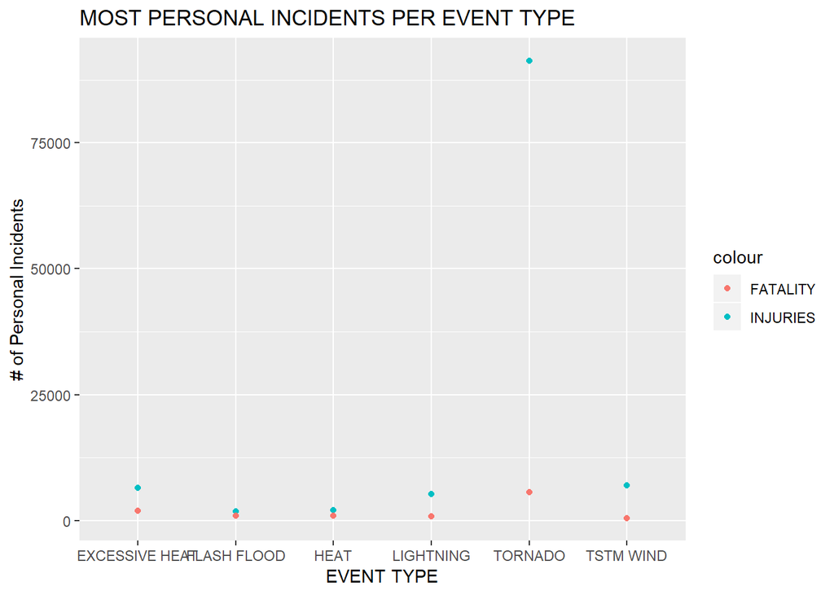

```r
g1<-ggplot(dfa2.4.1, aes(evt2.1))
g2<-g1 +
 geom_point(aes(y=SUMINJ, color="INJURIES")) +
 geom_point(aes(y=SUMFAT, color="FATALITY")) +
 labs(title="MOST PERSONAL INCIDENTS PER EVENT TYPE") +
 labs(x="EVENT TYPE",y="# of Personal Incidents")
print(g2)
```

## Entire U.S. Analysis for events with biggest economic consequence

Let’s organize the previous data sets to get a better look at events with the.highest property and crops damage

For events that cause the most property damage(SUMPROPDMG):

```r
dfa3.2<-dfa3.2[order(-dfa3.2$SUMPROPDMG),]
head(dfa3.2)
```

```
##       SUMPROPDMG SUMCROPDMG            EVTYPE
## 170 144657709807 5661968450             FLOOD
## 411  69305840000 2607872800 HURRICANE/TYPHOON
## 834  56947380677  414953270           TORNADO
## 670  43323536000       5000       STORM SURGE
## 153  16822673979 1421317100       FLASH FLOOD
## 244  15735267513 3025954473              HAIL
```

For events that cause the most crop damage(SUMCROPDMG):

```r
dfa3.3<-dfa3.2[order(-dfa3.2$SUMCROPDMG),]
head(dfa3.3)
```

```
##       SUMPROPDMG  SUMCROPDMG      EVTYPE
## 95    1046106000 13972566000     DROUGHT
## 170 144657709807  5661968450       FLOOD
## 590   5118945500  5029459000 RIVER FLOOD
## 427   3944927860  5022113500   ICE STORM
## 244  15735267513  3025954473        HAIL
## 402  11868319010  2741910000   HURRICANE
```

```r
dfa3.2.1<-dfa3.2[1:7,1:2]
evt3.1<-as.character(dfa3.2$EVTYPE[1:7])
dfa3.2.1<-cbind(dfa3.2.1, evt3.1)
dfa3.2.1
```

```
##       SUMPROPDMG SUMCROPDMG            evt3.1
## 170 144657709807 5661968450             FLOOD
## 411  69305840000 2607872800 HURRICANE/TYPHOON
## 834  56947380677  414953270           TORNADO
## 670  43323536000       5000       STORM SURGE
## 153  16822673979 1421317100       FLASH FLOOD
## 244  15735267513 3025954473              HAIL
## 402  11868319010 2741910000         HURRICANE
```

Let’s visualize our findings for property damage. We see floods cause the most property damage.

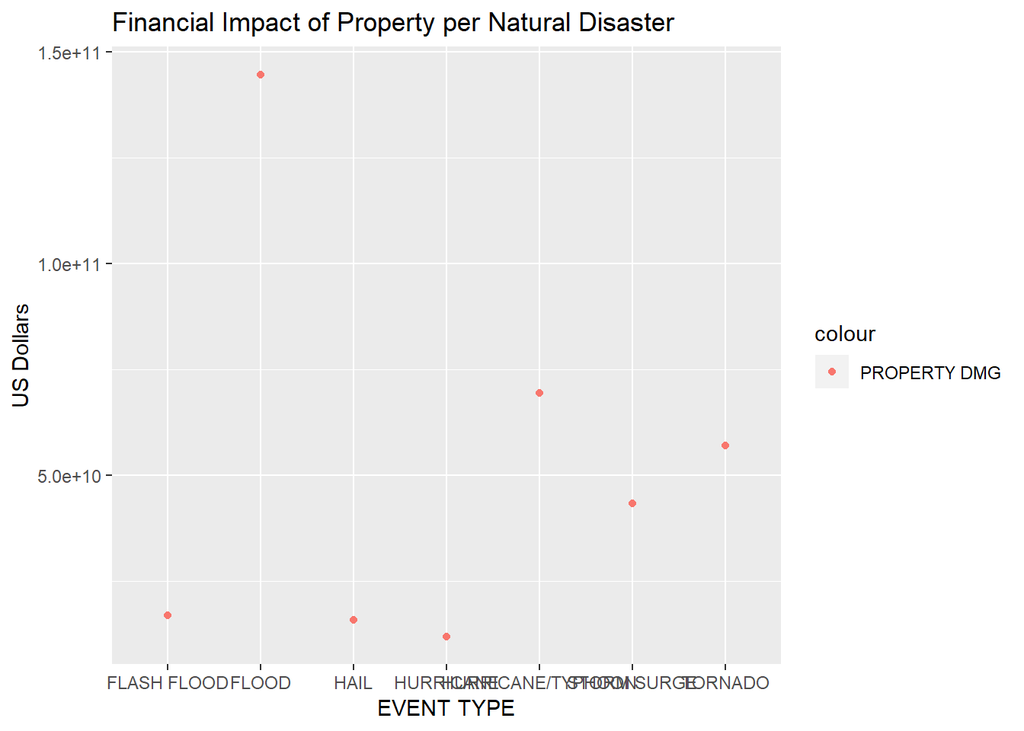

```r
g3.1<-ggplot(dfa3.2.1, aes(evt3.1)) #SUMPROPDMG, color="PROPERTY DMG"))
g3.2<-g3.1 +
  geom_point(aes(y=SUMPROPDMG, color="PROPERTY DMG")) +
#  geom_point(aes(y=SUMFAT, color="FATALITY")) +
  labs(title="Financial Impact of Property per Natural Disaster") +
  labs(x="EVENT TYPE",y="US Dollars")
print(g3.2)
```

```r
dfa3.3.1<-dfa3.3[1:5,1:2]
evt3.2<-as.character(dfa3.3$EVTYPE[1:5])
dfa3.3.1<-cbind(dfa3.3.1, evt3.2)
dfa3.3.1
```

```
##       SUMPROPDMG  SUMCROPDMG      evt3.2
## 95    1046106000 13972566000     DROUGHT
## 170 144657709807  5661968450       FLOOD
## 590   5118945500  5029459000 RIVER FLOOD
## 427   3944927860  5022113500   ICE STORM
## 244  15735267513  3025954473        HAIL
```

Let’s visualize our findings for crop damage. We see droughts cause the most damage to crops.

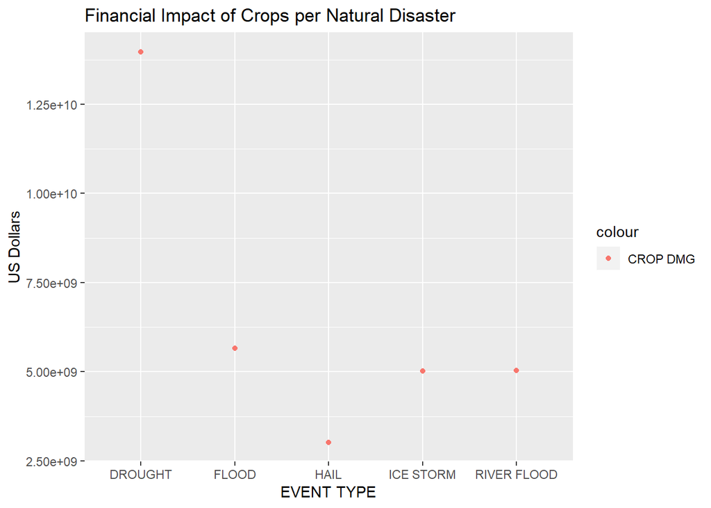

```r
g3.1.2<-ggplot(dfa3.3.1, aes(evt3.2))
g3.2.2<-g3.1.2 +
  geom_point(aes(y=SUMCROPDMG, color="CROP DMG")) +
  #  geom_point(aes(y=SUMFAT, color="FATALITY")) +
  labs(title="Financial Impact of Crops per Natural Disaster") +
  labs(x="EVENT TYPE",y="US Dollars")
print(g3.2.2)
```

## Conclusion

The intent of this report is to determine the most impactful natural events with regards to personal health, property, and agriculture. From this data, it is concluded that, on average across the U.S, tornadoes cause the most injuries as well as fatalities; the most property damage is caused by floods; and the most crop damage is caused by drought